# Experian_Excercise

# Visualization demo

## Started by importing libraries

```r
library(dplyr)
```

```r
library(tidyr)
library(ggplot2)
library(plotly)
library(stringr)
library(DataExplorer)
```

## And loading the dataset

```r
setwd("C:/Users/alfrs/Documents/git/RProjects/Experian")
dataset <- readxl::read_xlsx("DATA_FILE_FOR_INTERVIEW.xlsx")
head(dataset)
```

| COMPANY_NAME | CITY | STATE | ZIP | COUNTRY | PHONE | YEAR_INCORP | ANNUAL_SALES | EMPLOYEE_COUNT | NET_INCOME |
| --- | --- | --- | --- | --- | --- | --- | --- | --- | --- |
| AAR Corp | Wood Dale | IL | 60191 | USA | 630 227-2000 | 1955 | 2051800000 | 6550 | 7500000 |
| AFA Protective Systems, Inc. | Syosset | NY | 11791 | USA | 516 496-2322 | 1873 | 73220115 | 0 | 260050 |
| American Locker Group, Inc. | DFW Airport | TX | 75261 | USA | 817 329-1600 | 1898 | 14625889 | 120 | -2821386 |
| Abbott Laboratories | Abbott Park | IL | 60064 | USA | 224 667-6100 | 1900 | 30578000000 | 103000 | 2368000000 |
| ACMAT Corp. | Farmington | CT | 06032 | USA | 860 946-4800 | 1951 | 2750729 | NA | 743540 |
| Acme United Corp. | Fairfield | CT | 06824 | USA | 203 254-6060 | 1867 | 137321395 | 435 | 4598350 |

## Then I checked column types and reassigned those I thought needed reassignment

```r
str(dataset)
```

```
## Classes 'tbl_df', 'tbl' and 'data.frame':    8382 obs. of  10 variables:
##  $ COMPANY_NAME  : chr  "AAR Corp" "AFA Protective Systems, Inc." "American Locker Group, Inc." "Abbott Laboratories" ...
##  $ CITY          : chr  "Wood Dale" "Syosset" "DFW Airport" "Abbott Park" ...
##  $ STATE         : chr  "IL" "NY" "TX" "IL" ...
##  $ ZIP           : chr  "60191" "11791" "75261" "60064" ...
##  $ COUNTRY       : chr  "USA" "USA" "USA" "USA" ...
##  $ PHONE         : chr  "630 227-2000" "516 496-2322" "817 329-1600" "224 667-6100" ...
##  $ YEAR_INCORP   : chr  "1955" "1873" "1898" "1900" ...
##  $ ANNUAL_SALES  : num  2.05e+09 7.32e+07 1.46e+07 3.06e+10 2.75e+06 ...
##  $ EMPLOYEE_COUNT: num  6550 0 120 103000 NA 435 703 10100 16300 570 ...
##  $ NET_INCOME    : num  7.50e+06 2.60e+05 -2.82e+06 2.37e+09 7.44e+05 ...
```

```r
dataset$COMPANY_NAME <- as.factor(dataset$COMPANY_NAME)
dataset$CITY <- as.factor(dataset$CITY)
dataset$STATE <- as.factor(dataset$STATE)
dataset$ZIP <- as.factor(dataset$ZIP)
dataset$COUNTRY <- as.factor(dataset$COUNTRY)
dataset$PHONE <- as.factor(dataset$PHONE)
dataset$YEAR_INCORP <- as.numeric(dataset$YEAR_INCORP)
dataset$ANNUAL_SALES <- as.double(dataset$ANNUAL_SALES)
dataset$EMPLOYEE_COUNT <- as.double(dataset$EMPLOYEE_COUNT)
dataset$NET_INCOME <- as.double(dataset$NET_INCOME)

summary(dataset)
```

```
##                                COMPANY_NAME         CITY
##  024 Pharma Inc                      :   1   New York : 473
##  1-800 Flowers.com, Inc.             :   1   Houston  : 262
##  10x Genomics Inc                    :   1   Las Vegas: 188
##  11 Good Energy Inc                  :   1   Dallas   : 130
##  1347 Property Insurance Holdings Inc:   1   San Diego: 109
##  180 Degree Capital Corp             :   1   (Other)  :7117
##  (Other)                             :8376   NA's     : 103
##      STATE           ZIP          COUNTRY              PHONE
##  CA     :1280   10022  :  84   USA    :7283   800 983-0903:  11
##  NY     : 739   77002  :  67   CHN    : 308   855 588-7839:   8
##  TX     : 733   92121  :  47   CAN    : 205   510 522-9600:   7
##  FL     : 553   80202  :  43   HKG    :  91   512 236-6555:   6
##  NV     : 315   10019  :  36   ISR    :  80   800 736-3402:   6
##  (Other):4175   (Other):7968   (Other): 414   (Other)     :8310
##  NA's   : 587   NA's   : 137   NA's   :   1   NA's        :  34
##   YEAR_INCORP    ANNUAL_SALES        EMPLOYEE_COUNT
##  Min.   :1784   Min.   :-2.781e+08   Min.   :      0
##  1st Qu.:1986   1st Qu.: 4.095e+06   1st Qu.:     13
##  Median :1999   Median : 8.760e+07   Median :    187
##  Mean   :1991   Mean   : 2.709e+09   Mean   :   6671
##  3rd Qu.:2008   3rd Qu.: 9.903e+08   3rd Qu.:   2228
##  Max.   :2019   Max.   : 5.144e+11   Max.   :2200000
##  NA's   :157    NA's   :1625         NA's   :1668
##    NET_INCOME
##  Min.   :-2.244e+10
##  1st Qu.:-5.216e+06
##  Median :-7.610e+04
##  Mean   : 1.758e+08
##  3rd Qu.: 2.798e+07
##  Max.   : 5.953e+10
##  NA's   :25
```

## I started working on the first point. A distribution of companies by year sounded very easy, but the graph said otherwise.

```r
ggplotly(
ggplot(dataset %>% count(YEAR_INCORP),aes(x = YEAR_INCORP, y = n, fill = as.factor(YEAR_INCORP)))+
  geom_col()+
  #geom_text(aes(label = n),position = position_stack(vjust = .5)) +
  ggtitle("Count of Companies by Year Bucket")+
  theme(plot.title = element_text(hjust = 0.5),
        axis.text.x = element_blank(),
        axis.ticks.x = element_blank())+
  ylab("Count of Companies by Year") +
  labs(fill = "Year Incorporated") +
  coord_flip()
)
```

[interactive chart not shown]

## I then tried a histogram, sice we’re using years, maybe I can see which are the most valuable, however…

```r
ggplotly(
ggplot(dataset,aes(x = YEAR_INCORP))+
  geom_histogram()
)
```

[interactive chart not shown]

## The histogram did show me that most of my companies are arround the 2000’s

## But I can’t really see which year is the most valuable

## So I did year buckets, that would allow me to graph and see the data in a more manageable way

```r
dataset$YEAR_BUCKET <- cut(dataset$YEAR_INCORP,dig.lab=4,breaks=10)
dataset$YEAR_BUCKET <- str_replace(dataset$YEAR_BUCKET, "\\(", "")
dataset$YEAR_BUCKET <- str_replace(dataset$YEAR_BUCKET, "]", "")
dataset$YEAR_BUCKET <- str_replace(dataset$YEAR_BUCKET, ",", " - ")

dataset$YEAR_BUCKET <- as.factor(dataset$YEAR_BUCKET)

ggplotly(
ggplot(na.exclude(dataset) %>% count(YEAR_BUCKET),aes(x = YEAR_BUCKET, y = n, fill = as.factor(YEAR_BUCKET)))+
  geom_col()+
  geom_text(aes(label = n),position = position_stack(vjust = .5)) +
  ggtitle("Count of Companies by Year Bucket")+
  theme(plot.title = element_text(hjust = 0.5),
        axis.text.x = element_blank(),
        axis.ticks.x = element_blank())+
  ylab("Count of companies") +
  labs(fill = "Year Bucket") +
  coord_flip()
)
```

[interactive chart not shown]

## Thanks to the buckets, I saw that most of my data is from 1972 going forward. So I did buckets again, but only with these years.

```r
dataset_filtered <- dataset %>% filter(YEAR_INCORP >= 1972)
dataset_filtered$YEAR_BUCKET <- cut(dataset_filtered$YEAR_INCORP,dig.lab=4,breaks=10)
dataset_filtered$YEAR_BUCKET <- str_replace(dataset_filtered$YEAR_BUCKET, "\\(", "")
dataset_filtered$YEAR_BUCKET <- str_replace(dataset_filtered$YEAR_BUCKET, "]", "")
dataset_filtered$YEAR_BUCKET <- str_replace(dataset_filtered$YEAR_BUCKET, ",", " - ")

dataset_filtered$YEAR_BUCKET <- as.factor(dataset_filtered$YEAR_BUCKET)

summary(dataset_filtered)
```

```
##                                COMPANY_NAME         CITY
##  024 Pharma Inc                      :   1   New York : 400
##  1-800 Flowers.com, Inc.             :   1   Houston  : 223
##  10x Genomics Inc                    :   1   Las Vegas: 181
##  11 Good Energy Inc                  :   1   Dallas   : 106
##  1347 Property Insurance Holdings Inc:   1   San Diego: 104
##  180 Degree Capital Corp             :   1   (Other)  :5956
##  (Other)                             :7063   NA's     :  99
##      STATE           ZIP          COUNTRY              PHONE
##  CA     :1175   10022  :  73   USA    :6021   800 983-0903:  11
##  TX     : 622   77002  :  57   CHN    : 298   510 522-9600:   7
##  NY     : 599   92121  :  46   CAN    : 196   512 236-6555:   6
##  FL     : 487   80202  :  42   HKG    :  91   855 588-7839:   6
##  NV     : 298   94080  :  31   ISR    :  76   214 981-0700:   4
##  (Other):3331   (Other):6685   (Other): 386   (Other)     :7001
##  NA's   : 557   NA's   : 135   NA's   :   1   NA's        :  34
##   YEAR_INCORP    ANNUAL_SALES        EMPLOYEE_COUNT     NET_INCOME
##  Min.   :1972   Min.   :-2.781e+08   Min.   :     0   Min.   :-5.086e+09
##  1st Qu.:1993   1st Qu.: 2.045e+06   1st Qu.:     9   1st Qu.:-6.497e+06
##  Median :2003   Median : 4.817e+07   Median :   107   Median :-2.498e+05
##  Mean   :2000   Mean   : 1.781e+09   Mean   :  4014   Mean   : 1.167e+08
##  3rd Qu.:2009   3rd Qu.: 5.341e+08   3rd Qu.:  1122   3rd Qu.: 1.011e+07
##  Max.   :2019   Max.   : 2.656e+11   Max.   :647500   Max.   : 5.953e+10
##                 NA's   :1572         NA's   :1494     NA's   :20
##       YEAR_BUCKET
##  2005 - 2010:1498
##  2010 - 2014:1232
##  1996 - 2000:1050
##  2000 - 2005: 691
##  1991 - 1996: 615
##  1981 - 1986: 607
##  (Other)    :1376
```

## This graph looks better, now I can see that most of the companies got incorporated between 2005 and 2010.

```r
ggplotly(
ggplot(dataset_filtered %>% count(YEAR_BUCKET),aes(x = YEAR_BUCKET, y = n, fill = as.factor(YEAR_BUCKET)))+
  geom_col()+
  geom_text(aes(label = n),position = position_stack(vjust = .5)) +
  ggtitle("Count of Companies by Year Bucket")+
  theme(plot.title = element_text(hjust = 0.5),
        axis.text.x = element_blank(),
        axis.ticks.x = element_blank())+
  ylab("Count of passengers") +
  labs(fill = "Year Bucket") +
  coord_flip()
)
```

[interactive chart not shown]

## I then wanted to see a distribution of companies by employee count.

## But first, I wanted to see if we had any NAs in the data, and how can we replace them.

```r
dataset_emp <- dataset %>% select(EMPLOYEE_COUNT,COUNTRY) %>% filter(is.na(EMPLOYEE_COUNT)) %>% count(COUNTRY)

dataset_emp$COUNTRY <- factor(dataset_emp$COUNTRY, levels = dataset_emp$COUNTRY[order(dataset_emp$n,decreasing = TRUE)])

ggplotly(
dataset_emp %>% ggplot(aes(x=COUNTRY,y=n,fill=as.factor(n)))+geom_col()+
        theme(axis.text.x = element_text(size = 10, angle = 90, hjust = .5, vjust = .5),
        panel.background = element_blank(),
        plot.title = element_text(size = 25,face = "bold")) +
        ylab("Count of NAs") +
        xlab("Country") +
        labs(fill = "Count of NAs")
)
```

[interactive chart not shown]

## Unsurprisingly USA has the highest amount of NAs, which correlates with it having the highest amount of companies

## Then I wanted to see the variance of Employee Counts, of all countries where I had NAs, but where I had no NA values

```r
dataset_emp_noNA <-
dataset %>% select(EMPLOYEE_COUNT,COUNTRY) %>% filter(!is.na(EMPLOYEE_COUNT))

dataset_emp_noNA <- merge(dataset_emp_noNA %>% select(COUNTRY,EMPLOYEE_COUNT), dataset_emp %>% select(COUNTRY),all=FALSE)

ggplotly(
dataset_emp_noNA %>% ggplot(aes(x=COUNTRY,y=EMPLOYEE_COUNT))+geom_boxplot()+
        theme(axis.text.x = element_text(size = 10, angle = 90, hjust = .5, vjust = .5),
        panel.background = element_blank(),
        plot.title = element_text(size = 25,face = "bold")) +
        ylab("Employee Count") +
        xlab("Country")
)
```

[interactive chart not shown]

## The reason behind this is that the median doesn’t look weird for the countries, it actually sits very well with the data

```r
for (country in unique(dataset$COUNTRY)){
  dataset_fil <- dataset %>% filter(!is.na(EMPLOYEE_COUNT)) %>% filter(COUNTRY == country)
  dataset$EMPLOYEE_COUNT <- replace_na(dataset$EMPLOYEE_COUNT,quantile(na.exclude(dataset_fil$EMPLOYEE_COUNT),probs=0.5))
}

summary(dataset)
```

```
##                                COMPANY_NAME         CITY
##  024 Pharma Inc                      :   1   New York : 473
##  1-800 Flowers.com, Inc.             :   1   Houston  : 262
##  10x Genomics Inc                    :   1   Las Vegas: 188
##  11 Good Energy Inc                  :   1   Dallas   : 130
##  1347 Property Insurance Holdings Inc:   1   San Diego: 109
##  180 Degree Capital Corp             :   1   (Other)  :7117
##  (Other)                             :8376   NA's     : 103
##      STATE           ZIP          COUNTRY              PHONE
##  CA     :1280   10022  :  84   USA    :7283   800 983-0903:  11
##  NY     : 739   77002  :  67   CHN    : 308   855 588-7839:   8
##  TX     : 733   92121  :  47   CAN    : 205   510 522-9600:   7
##  FL     : 553   80202  :  43   HKG    :  91   512 236-6555:   6
##  NV     : 315   10019  :  36   ISR    :  80   800 736-3402:   6
##  (Other):4175   (Other):7968   (Other): 414   (Other)     :8310
##  NA's   : 587   NA's   : 137   NA's   :   1   NA's        :  34
##   YEAR_INCORP    ANNUAL_SALES        EMPLOYEE_COUNT
##  Min.   :1784   Min.   :-2.781e+08   Min.   :      0
##  1st Qu.:1986   1st Qu.: 4.095e+06   1st Qu.:     28
##  Median :1999   Median : 8.760e+07   Median :    207
##  Mean   :1991   Mean   : 2.709e+09   Mean   :   5385
##  3rd Qu.:2008   3rd Qu.: 9.903e+08   3rd Qu.:   1177
##  Max.   :2019   Max.   : 5.144e+11   Max.   :2200000
##  NA's   :157    NA's   :1625
##    NET_INCOME              YEAR_BUCKET
##  Min.   :-2.244e+10   1996 - 2019:4931
##  1st Qu.:-5.216e+06   1972 - 1996:2107
##  Median :-7.610e+04   1948 - 1972: 567
##  Mean   : 1.758e+08   1925 - 1948: 229
##  3rd Qu.: 2.798e+07   1902 - 1925: 221
##  Max.   : 5.953e+10   (Other)    : 170
##  NA's   :25           NA's       : 157
```

## I decided to use the same approach as before, where I created buckets to see the distribution

```r
dataset$EMPLOYEE_COUNT_BUCKET <- cut(dataset$EMPLOYEE_COUNT,breaks = 20,dig.lab = 10)
dataset$EMPLOYEE_COUNT_BUCKET <- str_replace(dataset$EMPLOYEE_COUNT_BUCKET, "\\(", "")
dataset$EMPLOYEE_COUNT_BUCKET <- str_replace(dataset$EMPLOYEE_COUNT_BUCKET, "]", "")
dataset$EMPLOYEE_COUNT_BUCKET <- str_replace(dataset$EMPLOYEE_COUNT_BUCKET, ",", " - ")
dataset$EMPLOYEE_COUNT_BUCKET <- str_replace(dataset$EMPLOYEE_COUNT_BUCKET, "-2200", "0")

dataset$EMPLOYEE_COUNT_BUCKET <- as.factor(dataset$EMPLOYEE_COUNT_BUCKET)

summary(dataset)
```

```
##                                COMPANY_NAME         CITY
##  024 Pharma Inc                      :   1   New York : 473
##  1-800 Flowers.com, Inc.             :   1   Houston  : 262
##  10x Genomics Inc                    :   1   Las Vegas: 188
##  11 Good Energy Inc                  :   1   Dallas   : 130
##  1347 Property Insurance Holdings Inc:   1   San Diego: 109
##  180 Degree Capital Corp             :   1   (Other)  :7117
##  (Other)                             :8376   NA's     : 103
##      STATE           ZIP          COUNTRY              PHONE
##  CA     :1280   10022  :  84   USA    :7283   800 983-0903:  11
##  NY     : 739   77002  :  67   CHN    : 308   855 588-7839:   8
##  TX     : 733   92121  :  47   CAN    : 205   510 522-9600:   7
##  FL     : 553   80202  :  43   HKG    :  91   512 236-6555:   6
##  NV     : 315   10019  :  36   ISR    :  80   800 736-3402:   6
##  (Other):4175   (Other):7968   (Other): 414   (Other)     :8310
##  NA's   : 587   NA's   : 137   NA's   :   1   NA's        :  34
##   YEAR_INCORP    ANNUAL_SALES        EMPLOYEE_COUNT
##  Min.   :1784   Min.   :-2.781e+08   Min.   :      0
##  1st Qu.:1986   1st Qu.: 4.095e+06   1st Qu.:     28
##  Median :1999   Median : 8.760e+07   Median :    207
##  Mean   :1991   Mean   : 2.709e+09   Mean   :   5385
##  3rd Qu.:2008   3rd Qu.: 9.903e+08   3rd Qu.:   1177
##  Max.   :2019   Max.   : 5.144e+11   Max.   :2200000
##  NA's   :157    NA's   :1625
##    NET_INCOME              YEAR_BUCKET         EMPLOYEE_COUNT_BUCKET
##  Min.   :-2.244e+10   1996 - 2019:4931   0 - 110000       :8315
##  1st Qu.:-5.216e+06   1972 - 1996:2107   110000 - 220000  :  37
##  Median :-7.610e+04   1948 - 1972: 567   2090000 - 2202200:   1
##  Mean   : 1.758e+08   1925 - 1948: 229   220000 - 330000  :  18
##  3rd Qu.: 2.798e+07   1902 - 1925: 221   330000 - 440000  :   5
##  Max.   : 5.953e+10   (Other)    : 170   440000 - 550000  :   5
##  NA's   :25           NA's       : 157   550000 - 660000  :   1
```

## And with the graphic, I realized that most companies have between 0 and 110,000 employees.

```r
ggplotly(
ggplot(dataset %>%
  count(EMPLOYEE_COUNT_BUCKET),aes(x = EMPLOYEE_COUNT_BUCKET,y=n,fill=EMPLOYEE_COUNT_BUCKET))+
  geom_col()+
  geom_text(aes(label = n),position = position_stack(vjust = .5)) +
  ggtitle("Count of Companies by Employee Number Bucket")+
  theme(plot.title = element_text(hjust = 0.5),
        axis.text.x = element_blank(),
        axis.ticks.x = element_blank())+
  ylab("Count of Companies") +
  coord_flip()
)
```

[interactive chart not shown]

## As a third point, I wanted to see the distribution by Country.

## This distribution sounds easy enough, but again, the graphic shows otherwise.

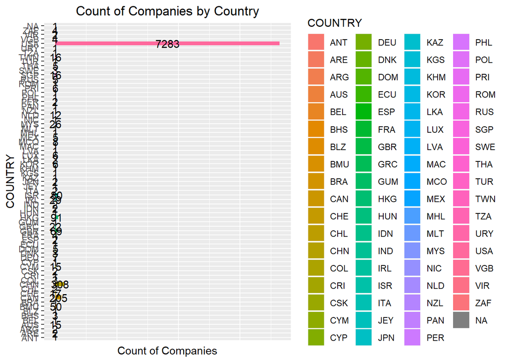

```r
ggplot(dataset %>% count(COUNTRY),aes(x=COUNTRY,y=n,fill=COUNTRY))+
  geom_col()+
  geom_text(aes(label = n),position = position_stack(vjust = .5)) +
  ggtitle("Count of Companies by Country")+
  theme(plot.title = element_text(hjust = 0.5),
        axis.text.x = element_blank(),
        axis.ticks.x = element_blank())+
  ylab("Count of Companies") +
  coord_flip()
```

## What I decided for this distribution, and since we have way too many countries, was that I wanted to see the top countries

## So I did the distribution, ordered the results by number of companies, and then took the top 10 companies

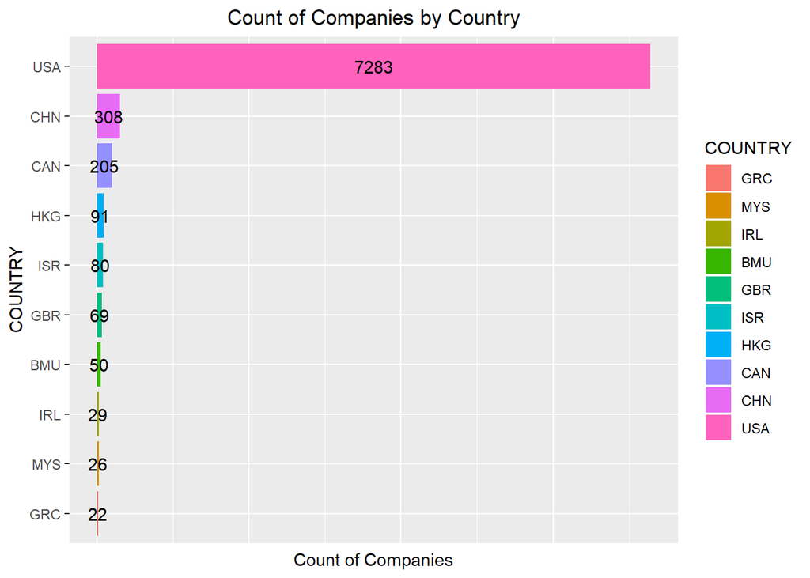

```r
dataset_country <- dataset %>% filter(!is.na(COUNTRY))

dataset_country_2 <- dataset_country %>% count(COUNTRY)

dataset_country_f <- tail(dataset_country_2[order(dataset_country_2$n),],10)

dataset_country_f$COUNTRY <- factor(dataset_country_f$COUNTRY, levels = dataset_country_f$COUNTRY[order(dataset_country_f$n)])

ggplot(dataset_country_f,aes(x=COUNTRY,y=n,fill=COUNTRY))+
  geom_col()+
  geom_text(aes(label = n),position = position_stack(vjust = .5)) +
  ggtitle("Count of Companies by Country")+
  theme(plot.title = element_text(hjust = 0.5),
        axis.text.x = element_blank(),
        axis.ticks.x = element_blank())+
  ylab("Count of Companies") +
  coord_flip()
```

## Unsurprinsingly, USA is the top country.

## What is noteworthy, is that the rest of the coutries have less than 5% of the companies that USA has